# Zimbabwe Revised Agro-Ecological Zones (AEZs)

Freedom K. Muranda

29 January 2025

# Report on Zimbabwe’s New Agro-Ecological Zones (AEZs)

## Introduction

Agro-Ecological Zones (AEZs) are essential for guiding agricultural practices, natural resource management, and policy planning. Zimbabwe’s newly revised AEZs address the changing climate, evolving land use, and the need for more precise zoning that reflects current environmental conditions. These updates align agricultural recommendations with emerging climate patterns, improving resource allocation to boost productivity and resilience (Manatsa et al., 2020).

## Revised AEZs

- **Region I**: High rainfall and cool temperatures, ideal for specialized crops like tea, coffee, and fruit.
- **Regions IIa and IIb**: Moderate rainfall areas supporting maize and tobacco production, with an increasing emphasis on drought-tolerant crops.
- **Region III**: Semi-arid, suited for livestock production and drought-tolerant crops.
- **Regions IV and V (Va and Vb)**: Arid to semi-arid zones with limited agricultural potential, focusing on extensive livestock systems and conservation agriculture.

## Key Changes

The revised AEZs reflect climate variability and its effects on rainfall patterns and crop suitability. Advanced Geographic Information Systems (GIS) techniques have been employed for mapping, providing more precise boundaries. Notable changes include:

- **Increased Detail**: Region V has been subdivided into Va and Vb to better distinguish agricultural suitability in the driest areas.
- **Climate Adaptation**: A stronger focus on drought-tolerant crops and water-efficient agricultural practices in marginal regions.
- **Modern Mapping Tools**: Improved zoning accuracy using GIS-based mapping techniques.

## Implications

These updated AEZs enhance Zimbabwe’s ability to implement climate-smart agricultural strategies. By offering precise guidance on land use, the zones help optimize crop selection, reduce climate risks, and encourage sustainable farming practices (Bofana et al., 2020). Policymakers and stakeholders can leverage this framework to address food security challenges, prioritize investments, and strengthen agricultural resilience (Bofana et al., 2020).

## Conclusion

The introduction of the new AEZs represents a significant advancement in adapting Zimbabwe’s agriculture to contemporary and future climate realities. They provide a solid foundation for informed decision-making, ensuring sustainable land use and improved livelihoods for farming communities. Ongoing research and monitoring are essential to fine-tune these zones and maximize their effectiveness.

```r
# Load necessary libraries
library(sf)
```

```r
library(ggplot2)

# Set the path to the Zimbabwe AEZ shapefile
shapefile_path <- "/Volumes/USB DISK/Research Project 2024/New_regions/Zim_regions.shp"

# Ensure the shapefile exists
if (!file.exists(shapefile_path)) {
  stop("Shapefile not found. Check the file path.")
}

# Load the shapefile
zimbabwe_aezs <- st_read(shapefile_path)
# Check and fix invalid geometries if necessary
if (!all(st_is_valid(zimbabwe_aezs))) {
  zimbabwe_aezs <- st_make_valid(zimbabwe_aezs)
}

# Print a summary of the data
print(st_geometry_type(zimbabwe_aezs))
```

```
## [1] MULTIPOLYGON MULTIPOLYGON MULTIPOLYGON MULTIPOLYGON MULTIPOLYGON
## [6] MULTIPOLYGON MULTIPOLYGON
## 18 Levels: GEOMETRY POINT LINESTRING POLYGON MULTIPOINT ... TRIANGLE
```

```r
print(names(zimbabwe_aezs))  # Show available columns
```

```
## [1] "Regions"  "ID2"      "ID3"      "geometry"
```

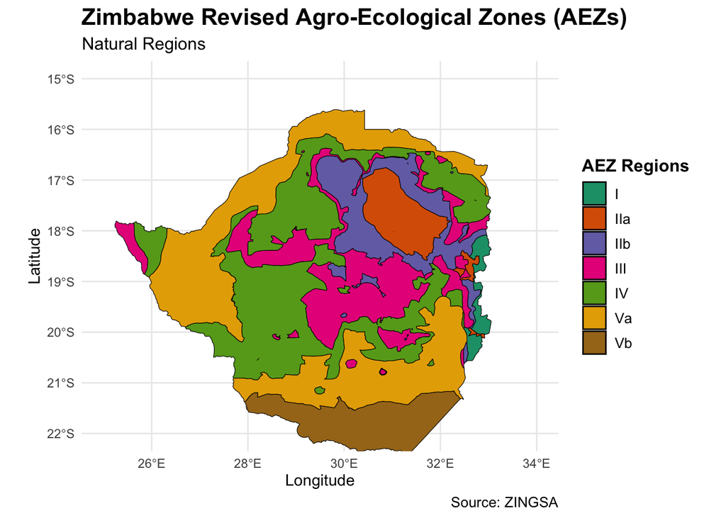

```r
# Generate the AEZ map with grid labels
ggplot(data = zimbabwe_aezs) +
  geom_sf(aes(fill = Regions), color = "black", size = 0.2) +
  scale_fill_manual(
    values = c(
      "I" = "#1b9e77",
      "IIa" = "#d95f02",
      "IIb" = "#7570b3",
      "III" = "#e7298a",
      "IV" = "#66a61e",
      "Va" = "#e6ab02",
      "Vb" = "#a6761d"
    ),
    name = "AEZ Regions"
  ) +
  theme_minimal() +
  coord_sf(
    xlim = c(25, 34),  # Adjust x-axis (longitude) range if necessary
    ylim = c(-22, -15), # Adjust y-axis (latitude) range if necessary
    expand = TRUE
  ) +
  labs(
    title = "Zimbabwe Revised Agro-Ecological Zones (AEZs)",
    subtitle = "Natural Regions",
    caption = "Source: ZINGSA",
    x = "Longitude",
    y = "Latitude"
  ) +
  theme(
    legend.position = "right",
    plot.title = element_text(size = 16, face = "bold"),
    plot.subtitle = element_text(size = 12),
    plot.caption = element_text(size = 10),
    legend.text = element_text(size = 10),
    legend.title = element_text(size = 12, face = "bold")
  )
```

```r
# Save the map output as a PDF
ggsave("Revised_AEZs.pdf", width = 10, height = 7)
```

## References

Bofana, J., Zhang, M., Nabil, M., Wu, B., Tian, F., Liu, W., Zeng, H., Zhang, N., Nangombe, S.S., Cipriano, S.A., Phiri, E., Mushore, T.D., Kaluba, P., Mashonjowa, E. & Moyo, C. (2020) Comparison of Different Cropland Classification Methods under Diversified Agroecological Conditions in the Zambezi River Basin. *Remote Sensing*. 12 (13), 2096. doi:10.3390/rs12132096.

Manatsa, D., Mushore, T.D., Gwitira, I., Wuta, M., Chemura, A., Shekede, M.D., Mugandani, R., Sakala, L.C., Ali, L.H. & Mupuro, J. (2020) *Revision of Zimbabwe’s agro-ecological zones. Produced by the Government of Zimbabwe under Zimbabwe National Geospatial and Space Agency (ZINGSA) for the Ministry of Higher and Tertiary Education, Innovation. Science and Technology Development*. Zimbabwe Government Printers. December.